# AI_PROJECT

```python
import pandas as pd
import numpy as np
import seaborn as sns
from  matplotlib import pyplot as plt
```

```python
from google.colab import drive
drive.mount('/content/drive')
```

```python
data_train=pd.read_csv ("/content/drive/MyDrive/AI CAPSTONE PROJECT/Financial/train_data.csv")
```

```python
data_train.head()
```

|  | Time | V1 | V2 | V3 | V4 | V5 | V6 | V7 | V8 | V9 | V10 | V11 | V12 | V13 | V14 | V15 | V16 | V17 | V18 | V19 | V20 | V21 | V22 | V23 | V24 | V25 | V26 | V27 | V28 | … |
| --- | --- | --- | --- | --- | --- | --- | --- | --- | --- | --- | --- | --- | --- | --- | --- | --- | --- | --- | --- | --- | --- | --- | --- | --- | --- | --- | --- | --- | --- | --- |
| 0 | 38355.0 | 1.043949 | 0.318555 | 1.045810 | 2.805989 | -0.561113 | -0.367956 | 0.032736 | -0.042333 | -0.322674 | 0.499167 | -0.572665 | 0.346009 | -0.047407 | -0.098964 | -0.663284 | 0.181411 | -0.124345 | -0.790453 | -0.720944 | -0.084556 | -0.240105 | -0.680315 | 0.085328 | 0.684812 | 0.318620 | -0.204963 | 0.001662 | 0.037894 | … |
| 1 | 22555.0 | -1.665159 | 0.808440 | 1.805627 | 1.903416 | -0.821627 | 0.934790 | -0.824802 | 0.975890 | 1.747469 | -0.658751 | 1.281502 | -1.430087 | 0.372028 | 1.403024 | -2.739413 | -1.331766 | 1.964590 | -0.205639 | 1.325588 | -0.373759 | -0.335332 | -0.510994 | 0.035839 | 0.147565 | -0.529358 | -0.566950 | -0.595998 | -0.220086 | … |
| 2 | 2431.0 | -0.324096 | 0.601836 | 0.865329 | -2.138000 | 0.294663 | -1.251553 | 1.072114 | -0.334896 | 1.071268 | -1.109522 | -1.016020 | -0.654945 | -1.473470 | 0.317345 | 1.067491 | -0.372642 | -0.674725 | 0.369841 | 0.095583 | -0.039868 | 0.012220 | 0.352856 | -0.341505 | -0.145791 | 0.094194 | -0.804026 | 0.229428 | -0.021623 | … |
| 3 | 86773.0 | -0.258270 | 1.217501 | -0.585348 | -0.875347 | 1.222481 | -0.311027 | 1.073860 | -0.161408 | 0.200665 | 0.154307 | 0.882673 | 0.547890 | 0.269484 | -1.253302 | -0.883963 | 0.495221 | -0.153212 | 0.296710 | 0.136148 | 0.382305 | -0.424626 | -0.781158 | 0.019316 | 0.178614 | -0.315616 | 0.096665 | 0.269740 | -0.020635 | … |
| 4 | 127202.0 | 2.142162 | -0.494988 | -1.936511 | -0.818288 | -0.025213 | -1.027245 | -0.151627 | -0.305750 | -0.869482 | 0.428729 | 1.136666 | 0.273476 | 0.697123 | -1.222134 | -0.938820 | 1.298149 | 0.912921 | -0.793721 | 1.064984 | 0.106592 | 0.010115 | 0.021722 | 0.079463 | -0.480899 | 0.023846 | -0.279076 | -0.030121 | -0.043888 | … |

```python
data_test=pd.read_csv("/content/drive/MyDrive/AI CAPSTONE PROJECT/Financial/test_data.csv")
```

```python
data_test_hidden=pd.read_csv("/content/drive/MyDrive/AI CAPSTONE PROJECT/Financial/test_data_hidden.csv")
```

```python
data_test.columns,data_test_hidden.columns
```

```
(Index(['Time', 'V1', 'V2', 'V3', 'V4', 'V5', 'V6', 'V7', 'V8', 'V9', 'V10',
        'V11', 'V12', 'V13', 'V14', 'V15', 'V16', 'V17', 'V18', 'V19', 'V20',
        'V21', 'V22', 'V23', 'V24', 'V25', 'V26', 'V27', 'V28', 'Amount'],
       dtype='object'),
 Index(['Time', 'V1', 'V2', 'V3', 'V4', 'V5', 'V6', 'V7', 'V8', 'V9', 'V10',
        'V11', 'V12', 'V13', 'V14', 'V15', 'V16', 'V17', 'V18', 'V19', 'V20',
        'V21', 'V22', 'V23', 'V24', 'V25', 'V26', 'V27', 'V28', 'Amount',
        'Class'],
       dtype='object'))
```

```python
data_test.head()
```

|  | Time | V1 | V2 | V3 | V4 | V5 | V6 | V7 | V8 | V9 | V10 | V11 | V12 | V13 | V14 | V15 | V16 | V17 | V18 | V19 | V20 | V21 | V22 | V23 | V24 | V25 | V26 | V27 | V28 | … |
| --- | --- | --- | --- | --- | --- | --- | --- | --- | --- | --- | --- | --- | --- | --- | --- | --- | --- | --- | --- | --- | --- | --- | --- | --- | --- | --- | --- | --- | --- | --- |
| 0 | 113050.0 | 0.114697 | 0.796303 | -0.149553 | -0.823011 | 0.878763 | -0.553152 | 0.939259 | -0.108502 | 0.111137 | -0.390521 | -1.949546 | -0.494436 | -0.353696 | 0.158729 | -0.267239 | 0.234802 | -0.754936 | -0.343012 | 0.312175 | -0.042711 | -0.335776 | -0.807853 | -0.055940 | -1.025281 | -0.369557 | 0.204653 | 0.242724 | 0.085713 | … |
| 1 | 26667.0 | -0.039318 | 0.495784 | -0.810884 | 0.546693 | 1.986257 | 4.386342 | -1.344891 | -1.743736 | -0.563103 | -0.616315 | -0.587786 | 0.317419 | -0.408521 | 0.719639 | 0.226926 | -0.296316 | -0.040143 | 0.119177 | 1.057682 | 0.926255 | -1.377003 | -0.072200 | -0.197573 | 1.014807 | 1.011293 | -0.167684 | 0.113136 | 0.256836 | … |
| 2 | 159519.0 | 2.275706 | -1.531508 | -1.021969 | -1.602152 | -1.220329 | -0.462376 | -1.196485 | -0.147058 | -0.950224 | 1.560463 | -1.753256 | -1.331010 | -0.061941 | -0.405532 | 0.048083 | -0.307503 | 0.289363 | 0.189739 | 0.022546 | -0.408289 | -0.193271 | -0.103533 | 0.150945 | -0.811083 | -0.197913 | -0.128446 | 0.014197 | -0.051289 | … |
| 3 | 137545.0 | 1.940137 | -0.357671 | -1.210551 | 0.382523 | 0.050823 | -0.171322 | -0.109124 | -0.002115 | 0.869258 | -0.001965 | 0.607629 | 1.048673 | -0.514821 | 0.329538 | -1.041463 | -0.498797 | -0.276887 | 0.114245 | 0.379447 | -0.199280 | 0.157994 | 0.650355 | 0.034206 | 0.739535 | 0.223605 | -0.195509 | -0.012791 | -0.056841 | … |
| 4 | 63369.0 | 1.081395 | -0.502615 | 1.075887 | -0.543359 | -1.472946 | -1.065484 | -0.443231 | -0.143374 | 1.659826 | -1.131238 | 0.173132 | 1.430172 | 0.915609 | -0.336588 | 1.140171 | -0.653626 | -0.016567 | 0.066287 | 0.242537 | 0.059880 | 0.224157 | 0.821209 | -0.137223 | 0.986259 | 0.563228 | -0.574206 | 0.089673 | 0.052036 | … |

```python
data_test_hidden.head()
```

|  | Time | V1 | V2 | V3 | V4 | V5 | V6 | V7 | V8 | V9 | V10 | V11 | V12 | V13 | V14 | V15 | V16 | V17 | V18 | V19 | V20 | V21 | V22 | V23 | V24 | V25 | V26 | V27 | V28 | … |
| --- | --- | --- | --- | --- | --- | --- | --- | --- | --- | --- | --- | --- | --- | --- | --- | --- | --- | --- | --- | --- | --- | --- | --- | --- | --- | --- | --- | --- | --- | --- |
| 0 | 113050.0 | 0.114697 | 0.796303 | -0.149553 | -0.823011 | 0.878763 | -0.553152 | 0.939259 | -0.108502 | 0.111137 | -0.390521 | -1.949546 | -0.494436 | -0.353696 | 0.158729 | -0.267239 | 0.234802 | -0.754936 | -0.343012 | 0.312175 | -0.042711 | -0.335776 | -0.807853 | -0.055940 | -1.025281 | -0.369557 | 0.204653 | 0.242724 | 0.085713 | … |
| 1 | 26667.0 | -0.039318 | 0.495784 | -0.810884 | 0.546693 | 1.986257 | 4.386342 | -1.344891 | -1.743736 | -0.563103 | -0.616315 | -0.587786 | 0.317419 | -0.408521 | 0.719639 | 0.226926 | -0.296316 | -0.040143 | 0.119177 | 1.057682 | 0.926255 | -1.377003 | -0.072200 | -0.197573 | 1.014807 | 1.011293 | -0.167684 | 0.113136 | 0.256836 | … |
| 2 | 159519.0 | 2.275706 | -1.531508 | -1.021969 | -1.602152 | -1.220329 | -0.462376 | -1.196485 | -0.147058 | -0.950224 | 1.560463 | -1.753256 | -1.331010 | -0.061941 | -0.405532 | 0.048083 | -0.307503 | 0.289363 | 0.189739 | 0.022546 | -0.408289 | -0.193271 | -0.103533 | 0.150945 | -0.811083 | -0.197913 | -0.128446 | 0.014197 | -0.051289 | … |
| 3 | 137545.0 | 1.940137 | -0.357671 | -1.210551 | 0.382523 | 0.050823 | -0.171322 | -0.109124 | -0.002115 | 0.869258 | -0.001965 | 0.607629 | 1.048673 | -0.514821 | 0.329538 | -1.041463 | -0.498797 | -0.276887 | 0.114245 | 0.379447 | -0.199280 | 0.157994 | 0.650355 | 0.034206 | 0.739535 | 0.223605 | -0.195509 | -0.012791 | -0.056841 | … |
| 4 | 63369.0 | 1.081395 | -0.502615 | 1.075887 | -0.543359 | -1.472946 | -1.065484 | -0.443231 | -0.143374 | 1.659826 | -1.131238 | 0.173132 | 1.430172 | 0.915609 | -0.336588 | 1.140171 | -0.653626 | -0.016567 | 0.066287 | 0.242537 | 0.059880 | 0.224157 | 0.821209 | -0.137223 | 0.986259 | 0.563228 | -0.574206 | 0.089673 | 0.052036 | … |

```python
data_train.eq(0).sum(),data_test.eq(0).sum()
```

```
(Time           2
 V1             0
 V2             0
 V3             0
 V4             0
 V5             0
 V6             0
 V7             0
 V8             0
 V9             0
 V10            0
 V11            0
 V12            0
 V13            0
 V14            0
 V15            0
 V16            0
 V17            0
 V18            0
 V19            0
 V20            0
 V21            0
 V22            0
 V23            0
 V24            0
 V25            0
 V26            0
 V27            0
 V28            0
 Amount      1467
 Class     227451
 dtype: int64, Time        0
 V1          0
 V2          0
 V3          0
 V4          0
 V5          0
 V6          0
 V7          0
 V8          0
 V9          0
 V10         0
 V11         0
 V12         0
 V13         0
 V14         0
 V15         0
 V16         0
 V17         0
 V18         0
 V19         0
 V20         0
 V21         0
 V22         0
 V23         0
 V24         0
 V25         0
 V26         0
 V27         0
 V28         0
 Amount    358
 dtype: int64)
```

**Checking the shape of the three datasets provided**

```python
data_train.shape,data_test.shape,data_test_hidden.shape
```

```
((227845, 31), (56962, 30), (56962, 31))
```

```python
data_train.corr()
```

|  | Time | V1 | V2 | V3 | V4 | V5 | V6 | V7 | V8 | V9 | V10 | V11 | V12 | V13 | V14 | V15 | V16 | V17 | V18 | V19 | V20 | V21 | V22 | V23 | V24 | V25 | V26 | V27 | V28 | … |
| --- | --- | --- | --- | --- | --- | --- | --- | --- | --- | --- | --- | --- | --- | --- | --- | --- | --- | --- | --- | --- | --- | --- | --- | --- | --- | --- | --- | --- | --- | --- |
| Time | 1.000000 | 0.117777 | -0.010475 | -0.419784 | -0.105047 | 0.173334 | -0.063703 | 0.084606 | -0.036989 | -0.009281 | 0.030671 | -0.249075 | 0.124282 | -0.066625 | -0.098673 | -0.183040 | 0.011148 | -0.073465 | 0.092087 | 0.028649 | -0.051160 | 0.044253 | 0.144670 | 0.049683 | -0.015547 | -0.231976 | -0.040369 | -0.005736 | -0.009289 | … |
| V1 | 0.117777 | 1.000000 | 0.008229 | 0.001239 | -0.002554 | -0.003554 | 0.003348 | 0.002552 | -0.001899 | 0.001410 | 0.001575 | -0.000925 | -0.001735 | -0.000463 | -0.001540 | -0.000989 | -0.002626 | -0.000568 | 0.000267 | 0.000583 | -0.002032 | -0.001978 | 0.002074 | 0.010848 | -0.001089 | 0.003159 | 0.002461 | 0.014184 | -0.013830 | … |
| V2 | -0.010475 | 0.008229 | 1.000000 | 0.003076 | -0.001860 | -0.004229 | 0.001530 | 0.001980 | -0.000321 | -0.002448 | -0.004113 | -0.000226 | -0.001595 | -0.001058 | -0.000624 | -0.000925 | -0.002382 | -0.001191 | 0.001879 | 0.002284 | -0.009700 | -0.003032 | 0.004273 | 0.007231 | 0.002603 | 0.003127 | 0.002701 | 0.013555 | -0.015893 | … |
| V3 | -0.419784 | 0.001239 | 0.003076 | 1.000000 | -0.001147 | -0.005848 | 0.004419 | 0.007959 | 0.000722 | 0.000356 | 0.000990 | 0.001510 | -0.000445 | -0.000625 | -0.002743 | 0.001516 | 0.001657 | -0.000760 | 0.001047 | 0.001547 | -0.006893 | -0.002979 | 0.001248 | 0.008481 | -0.000150 | 0.003749 | 0.001626 | 0.013268 | -0.009067 | … |
| V4 | -0.105047 | -0.002554 | -0.001860 | -0.001147 | 1.000000 | 0.001981 | -0.003068 | -0.003616 | -0.001397 | 0.000070 | 0.001005 | 0.003250 | 0.001564 | -0.000548 | 0.001915 | -0.001500 | -0.001814 | -0.001052 | 0.001431 | -0.001817 | 0.003787 | 0.003349 | -0.002147 | -0.001533 | -0.001154 | -0.000707 | -0.000590 | -0.007427 | 0.004131 | … |
| V5 | 0.173334 | -0.003554 | -0.004229 | -0.005848 | 0.001981 | 1.000000 | 0.014932 | 0.025536 | -0.004610 | -0.000297 | -0.003156 | 0.001762 | -0.003938 | 0.001445 | -0.001382 | 0.002530 | 0.003845 | -0.002759 | 0.000495 | 0.001780 | -0.016817 | -0.008510 | 0.002784 | 0.007772 | 0.000823 | 0.004833 | 0.002322 | 0.022597 | -0.010706 | … |
| V6 | -0.063703 | 0.003348 | 0.001530 | 0.004419 | -0.003068 | 0.014932 | 1.000000 | -0.017351 | 0.004478 | 0.000179 | 0.001427 | -0.000244 | 0.000958 | -0.000971 | 0.002442 | -0.002707 | -0.004873 | -0.000066 | -0.000894 | -0.000916 | 0.011611 | 0.005147 | -0.002171 | -0.003562 | -0.001478 | -0.002102 | -0.002203 | -0.012878 | 0.008897 | … |
| V7 | 0.084606 | 0.002552 | 0.001980 | 0.007959 | -0.003616 | 0.025536 | -0.017351 | 1.000000 | 0.007750 | 0.003864 | 0.007053 | -0.000213 | 0.006388 | -0.001361 | 0.002486 | -0.002471 | -0.003515 | 0.005135 | 0.002213 | -0.003600 | 0.021419 | 0.009986 | -0.003077 | -0.008366 | -0.002986 | -0.003375 | -0.004025 | -0.025285 | 0.017643 | … |
| V8 | -0.036989 | -0.001899 | -0.000321 | 0.000722 | -0.001397 | -0.004610 | 0.004478 | 0.007750 | 1.000000 | -0.000134 | 0.002166 | -0.002407 | 0.003678 | 0.002506 | 0.004858 | 0.001618 | 0.004699 | 0.005369 | 0.003033 | -0.000373 | -0.005609 | -0.000250 | -0.001087 | 0.005675 | 0.001012 | 0.002866 | 0.001722 | 0.006867 | -0.009391 | … |
| V9 | -0.009281 | 0.001410 | -0.002448 | 0.000356 | 0.000070 | -0.000297 | 0.000179 | 0.003864 | -0.000134 | 1.000000 | -0.000698 | 0.001382 | 0.000656 | 0.001798 | 0.000575 | 0.002350 | 0.001387 | 0.002512 | 0.001363 | 0.001724 | -0.005520 | -0.001672 | -0.001095 | -0.002803 | 0.000655 | -0.001328 | 0.000409 | 0.000861 | 0.003987 | … |
| V10 | 0.030671 | 0.001575 | -0.004113 | 0.000990 | 0.001005 | -0.003156 | 0.001427 | 0.007053 | 0.002166 | -0.000698 | 1.000000 | -0.000331 | 0.001386 | -0.001339 | -0.000151 | 0.000386 | 0.003860 | 0.002205 | 0.001675 | 0.001178 | -0.006727 | -0.003130 | 0.000088 | -0.000647 | 0.000737 | -0.000054 | 0.001100 | 0.003633 | 0.001012 | … |
| V11 | -0.249075 | -0.000925 | -0.000226 | 0.001510 | 0.003250 | 0.001762 | -0.000244 | -0.000213 | -0.002407 | 0.001382 | -0.000331 | 1.000000 | -0.000699 | -0.000167 | 0.001096 | 0.001853 | -0.000200 | 0.000460 | -0.002124 | 0.000977 | 0.000344 | 0.000816 | 0.000030 | 0.002191 | -0.000692 | -0.001255 | 0.000354 | -0.003505 | 0.003802 | … |
| V12 | 0.124282 | -0.001735 | -0.001595 | -0.000445 | 0.001564 | -0.003938 | 0.000958 | 0.006388 | 0.003678 | 0.000656 | 0.001386 | -0.000699 | 1.000000 | -0.000614 | -0.000278 | 0.000431 | -0.000053 | -0.000741 | 0.000238 | -0.000173 | -0.004597 | -0.000582 | -0.000502 | 0.000464 | 0.000243 | 0.000539 | 0.001393 | 0.003483 | -0.001420 | … |
| V13 | -0.066625 | -0.000463 | -0.001058 | -0.000625 | -0.000548 | 0.001445 | -0.000971 | -0.001361 | 0.002506 | 0.001798 | -0.001339 | -0.000167 | -0.000614 | 1.000000 | 0.000348 | 0.002084 | 0.000172 | 0.000592 | 0.001104 | -0.002623 | 0.001111 | 0.000272 | 0.000276 | -0.001214 | 0.000381 | -0.001991 | -0.001184 | -0.004479 | 0.001209 | … |
| V14 | -0.098673 | -0.001540 | -0.000624 | -0.002743 | 0.001915 | -0.001382 | 0.002442 | 0.002486 | 0.004858 | 0.000575 | -0.000151 | 0.001096 | -0.000278 | 0.000348 | 1.000000 | 0.000613 | 0.002461 | 0.000771 | 0.000206 | -0.002507 | 0.001126 | -0.001935 | 0.001396 | 0.000020 | -0.000841 | 0.001875 | -0.001374 | 0.001623 | -0.003638 | … |
| V15 | -0.183040 | -0.000989 | -0.000925 | 0.001516 | -0.001500 | 0.002530 | -0.002707 | -0.002471 | 0.001618 | 0.002350 | 0.000386 | 0.001853 | 0.000431 | 0.002084 | 0.000613 | 1.000000 | -0.001718 | 0.000437 | -0.000865 | -0.000774 | -0.000107 | 0.001392 | -0.000730 | -0.001792 | 0.001198 | -0.002857 | -0.001119 | -0.003624 | 0.005619 | … |
| V16 | 0.011148 | -0.002626 | -0.002382 | 0.001657 | -0.001814 | 0.003845 | -0.004873 | -0.003515 | 0.004699 | 0.001387 | 0.003860 | -0.000200 | -0.000053 | 0.000172 | 0.002461 | -0.001718 | 1.000000 | 0.002626 | 0.001034 | 0.001762 | 0.002739 | 0.003097 | -0.002450 | -0.005952 | 0.000610 | -0.000658 | -0.001295 | -0.006406 | 0.005165 | … |
| V17 | -0.073465 | -0.000568 | -0.001191 | -0.000760 | -0.001052 | -0.002759 | -0.000066 | 0.005135 | 0.005369 | 0.002512 | 0.002205 | 0.000460 | -0.000741 | 0.000592 | 0.000771 | 0.000437 | 0.002626 | 1.000000 | 0.000665 | -0.000507 | -0.000987 | 0.000445 | -0.000404 | -0.000381 | 0.000838 | 0.000736 | 0.000540 | 0.004757 | -0.002350 | … |
| V18 | 0.092087 | 0.000267 | 0.001879 | 0.001047 | 0.001431 | 0.000495 | -0.000894 | 0.002213 | 0.003033 | 0.001363 | 0.001675 | -0.002124 | 0.000238 | 0.001104 | 0.000206 | -0.000865 | 0.001034 | 0.000665 | 1.000000 | 0.000278 | 0.001211 | 0.001289 | -0.001111 | 0.001496 | 0.001445 | 0.000802 | -0.000488 | 0.002055 | -0.003434 | … |
| V19 | 0.028649 | 0.000583 | 0.002284 | 0.001547 | -0.001817 | 0.001780 | -0.000916 | -0.003600 | -0.000373 | 0.001724 | 0.001178 | 0.000977 | -0.000173 | -0.002623 | -0.002507 | -0.000774 | 0.001762 | -0.000507 | 0.000278 | 1.000000 | -0.000780 | 0.001622 | -0.001137 | -0.001297 | 0.000414 | 0.000786 | -0.000439 | -0.003476 | 0.002329 | … |
| V20 | -0.051160 | -0.002032 | -0.009700 | -0.006893 | 0.003787 | -0.016817 | 0.011611 | 0.021419 | -0.005609 | -0.005520 | -0.006727 | 0.000344 | -0.004597 | 0.001111 | 0.001126 | -0.000107 | 0.002739 | -0.000987 | 0.001211 | -0.000780 | 1.000000 | -0.000435 | 0.001689 | 0.013348 | 0.001558 | 0.002580 | 0.002351 | 0.025160 | -0.023010 | … |
| V21 | 0.044253 | -0.001978 | -0.003032 | -0.002979 | 0.003349 | -0.008510 | 0.005147 | 0.009986 | -0.000250 | -0.001672 | -0.003130 | 0.000816 | -0.000582 | 0.000272 | -0.001935 | 0.001392 | 0.003097 | 0.000445 | 0.001289 | 0.001622 | -0.000435 | 1.000000 | 0.002411 | 0.005986 | -0.000591 | 0.003180 | 0.001287 | 0.012752 | -0.011497 | … |
| V22 | 0.144670 | 0.002074 | 0.004273 | 0.001248 | -0.002147 | 0.002784 | -0.002171 | -0.003077 | -0.001087 | -0.001095 | 0.000088 | 0.000030 | -0.000502 | 0.000276 | 0.001396 | -0.000730 | -0.002450 | -0.000404 | -0.001111 | -0.001137 | 0.001689 | 0.002411 | 1.000000 | -0.001151 | -0.001437 | -0.000921 | 0.000424 | -0.003481 | 0.001312 | … |
| V23 | 0.049683 | 0.010848 | 0.007231 | 0.008481 | -0.001533 | 0.007772 | -0.003562 | -0.008366 | 0.005675 | -0.002803 | -0.000647 | 0.002191 | 0.000464 | -0.001214 | 0.000020 | -0.001792 | -0.005952 | -0.000381 | 0.001496 | -0.001297 | 0.013348 | 0.005986 | -0.001151 | 1.000000 | -0.003250 | -0.001691 | -0.000300 | -0.001166 | -0.001869 | … |
| V24 | -0.015547 | -0.001089 | 0.002603 | -0.000150 | -0.001154 | 0.000823 | -0.001478 | -0.002986 | 0.001012 | 0.000655 | 0.000737 | -0.000692 | 0.000243 | 0.000381 | -0.000841 | 0.001198 | 0.000610 | 0.000838 | 0.001445 | 0.000414 | 0.001558 | -0.000591 | -0.001437 | -0.003250 | 1.000000 | 0.000881 | -0.001981 | -0.002252 | 0.003436 | … |
| V25 | -0.231976 | 0.003159 | 0.003127 | 0.003749 | -0.000707 | 0.004833 | -0.002102 | -0.003375 | 0.002866 | -0.001328 | -0.000054 | -0.001255 | 0.000539 | -0.001991 | 0.001875 | -0.002857 | -0.000658 | 0.000736 | 0.000802 | 0.000786 | 0.002580 | 0.003180 | -0.000921 | -0.001691 | 0.000881 | 1.000000 | 0.001031 | -0.004543 | 0.001009 | … |
| V26 | -0.040369 | 0.002461 | 0.002701 | 0.001626 | -0.000590 | 0.002322 | -0.002203 | -0.004025 | 0.001722 | 0.000409 | 0.001100 | 0.000354 | 0.001393 | -0.001184 | -0.001374 | -0.001119 | -0.001295 | 0.000540 | -0.000488 | -0.000439 | 0.002351 | 0.001287 | 0.000424 | -0.000300 | -0.001981 | 0.001031 | 1.000000 | -0.002380 | 0.001364 | … |
| V27 | -0.005736 | 0.014184 | 0.013555 | 0.013268 | -0.007427 | 0.022597 | -0.012878 | -0.025285 | 0.006867 | 0.000861 | 0.003633 | -0.003505 | 0.003483 | -0.004479 | 0.001623 | -0.003624 | -0.006406 | 0.004757 | 0.002055 | -0.003476 | 0.025160 | 0.012752 | -0.003481 | -0.001166 | -0.002252 | -0.004543 | -0.002380 | 1.000000 | 0.006418 | … |
| V28 | -0.009289 | -0.013830 | -0.015893 | -0.009067 | 0.004131 | -0.010706 | 0.008897 | 0.017643 | -0.009391 | 0.003987 | 0.001012 | 0.003802 | -0.001420 | 0.001209 | -0.003638 | 0.005619 | 0.005165 | -0.002350 | -0.003434 | 0.002329 | -0.023010 | -0.011497 | 0.001312 | -0.001869 | 0.003436 | 0.001009 | 0.001364 | 0.006418 | 1.000000 | … |
| Amount | -0.011328 | -0.228808 | -0.537855 | -0.207587 | 0.098695 | -0.367801 | 0.201285 | 0.377417 | -0.097939 | -0.044312 | -0.099188 | -0.001032 | -0.005946 | 0.004013 | 0.037325 | -0.006642 | -0.008466 | 0.010491 | 0.035866 | -0.061405 | 0.378698 | 0.122292 | -0.070336 | -0.117349 | 0.001810 | -0.053393 | -0.008603 | -0.004428 | 0.033896 | … |
| Class | -0.012800 | -0.103095 | 0.093795 | -0.196385 | 0.134044 | -0.099712 | -0.042548 | -0.196860 | 0.013376 | -0.099674 | -0.222186 | 0.156553 | -0.262903 | -0.003179 | -0.304232 | -0.004350 | -0.201828 | -0.333463 | -0.114699 | 0.036724 | 0.021953 | 0.042515 | 0.000425 | -0.001647 | -0.007020 | 0.003089 | 0.004288 | 0.016901 | 0.010773 | … |

**Creating separate dataframes for fraudulent and non-fradulent records**

```python
data_fraud=data_train.loc[data_train['Class']==1]
data_normal=data_train.loc[data_train['Class']==0]
```

```python
print("Total number of fraudulent transactions are", len(data_fraud))
print("Total number of non fradulent TRANSCATIONS are", len(data_normal))
```

```
Total number of fraudulent transactions are 394
Total number of non fradulent TRANSCATIONS are 227451
```

**Storing the number of fraudulent and non fraudulent transactions in variable called count_class**

```python
count_class = data_train.Class.value_counts()
count_class
```

```
0    227451
1       394
Name: Class, dtype: int64
```

**Visualise the count of normal and fraud transactions**

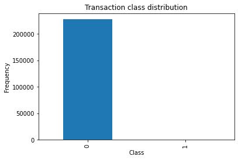

```python
plt.title('Transaction class distribution')
LABELS =['Normal','Fraud']
plt.xlabel('Class')
plt.xticks(range(2),LABELS)
plt.ylabel('Frequency')
count_class.plot(kind='bar')
```

**Visualizing the Amount per transaction in both fraudulent and non fraudulent transactions**

```python
data_fraud.Amount.describe()
```

```
count     394.000000
mean      127.306523
std       264.533907
min         0.000000
25%         1.000000
50%        11.395000
75%       106.385000
max      2125.870000
Name: Amount, dtype: float64
```

```python
data_normal.Amount.describe()
```

```
count    227451.000000
mean         88.455144
std         248.066088
min           0.000000
25%           5.640000
50%          22.000000
75%          77.000000
max       19656.530000
Name: Amount, dtype: float64
```

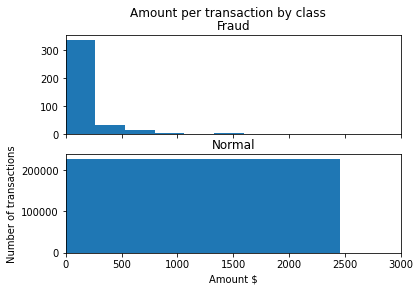

```python
fraud1,(ax1, ax2) = plt.subplots(2,1, sharex=True)
fraud1.suptitle("Amount per transaction by class")

bins = 8
ax1.hist(data_fraud.Amount, bins=bins)
ax2.hist(data_normal.Amount, bins = bins)
ax1.set_title("Fraud")
ax2.set_title("Normal")

plt.xlabel("Amount $")
plt.ylabel("Number of transactions")
plt.xlim(0,3000)
plt.yscale = ('log')
plt.show()
```

**HANDLING IMBALANCED DATASET**

```python
!pip install imblearn
```

**Logistic Regression model on unbalanced data**

```python
from sklearn.linear_model import LogisticRegression
from sklearn.model_selection import train_test_split
from sklearn.metrics import confusion_matrix,accuracy_score,classification_report,f1_score,roc_auc_score
```

```python
model_log = LogisticRegression()
```

```python
X= data_train.drop('Class',axis =1)
Y = data_train['Class']
ytest = data_test_hidden['Class']
```

```python
X_train,X_val,Y_train,Y_val = train_test_split(X,Y,test_size = 0.2,random_state = 2,stratify = Y)
model_log.fit(X_train,Y_train)
```

```
LogisticRegression()
```

```python
#prediction on train data (unbalanced)
Y_train_prediction = model_log.predict(X_train)
print(classification_report(Y_train,Y_train_prediction))
```

```
              precision    recall  f1-score   support

           0       1.00      1.00      1.00    181961
           1       0.80      0.69      0.74       315

    accuracy                           1.00    182276
   macro avg       0.90      0.84      0.87    182276
weighted avg       1.00      1.00      1.00    182276
```

```python
# prediction on test data (fitting done on unbalanced data)
Y_test_prediction = model_log.predict(data_test)
print(classification_report(ytest,Y_test_prediction))
```

```
              precision    recall  f1-score   support

           0       1.00      1.00      1.00     56864
           1       0.75      0.63      0.69        98

    accuracy                           1.00     56962
   macro avg       0.87      0.82      0.84     56962
weighted avg       1.00      1.00      1.00     56962
```

**Undersampling the data**

```python
data_normal_under = data_normal.sample(count_class[1])
```

```python
data_normal_under.shape
```

```
(394, 31)
```

```python
data_under = pd.concat([data_normal_under,data_fraud],axis = 0)
```

```python
data_under.Class.value_counts()
```

```
1    394
0    394
Name: Class, dtype: int64
```

```python
data_under.shape
```

```
(788, 31)
```

```python
x = data_under.drop('Class',axis =1)
y = data_under['Class']
```

```python
# Splitting the undersampled data into train and test set
Xtrain,Xval,Ytrain,Yval = train_test_split(x,y,test_size = 0.2,random_state = 42,stratify = y)
```

```python
Ytrain.value_counts()
```

```
1    315
0    315
Name: Class, dtype: int64
```

**Applying Logistic Regression Model to the data after undersampling**

```python
model1_log = LogisticRegression()
model1_log.fit(Xtrain,Ytrain)
```

```
LogisticRegression()
```

```python
# model Evaluation

# Report for logistic regression (after undersampling) on train data
yunder_log_pred = model1_log.predict(Xtrain)
#printytest_under_pred)
print("ROC_AUC-SCORE obtained after logistic regression modeling on the undersampled train data is",roc_auc_score(Ytrain,yunder_log_pred))
print(classification_report(Ytrain,yunder_log_pred))
print("F1 SCORE obtained after logistic regression modeling on the undersampled train data is", f1_score(Ytrain,yunder_log_pred))
```

```
ROC_AUC-SCORE obtained after logistic regression modeling on the undersampled train data is 0.9555555555555556
              precision    recall  f1-score   support

           0       0.93      0.98      0.96       315
           1       0.98      0.93      0.95       315

    accuracy                           0.96       630
   macro avg       0.96      0.96      0.96       630
weighted avg       0.96      0.96      0.96       630

F1 SCORE obtained after logistic regression modeling on the undersampled train data is 0.9543973941368079
```

```python
# Report for logistic regression (after undersampling) on test data

ytest_under_pred = model1_log.predict(data_test)

print(classification_report(ytest,ytest_under_pred))
print("ROC_AUC-SCORE obtained after logistic regression modeling on the test data is", roc_auc_score(ytest,ytest_under_pred))
print("F1 SCORE obtained after logistic regression modeling on the test data is", f1_score(ytest,ytest_under_pred))
```

```
              precision    recall  f1-score   support

           0       1.00      0.96      0.98     56864
           1       0.03      0.88      0.06        98

    accuracy                           0.96     56962
   macro avg       0.52      0.92      0.52     56962
weighted avg       1.00      0.96      0.98     56962

ROC_AUC-SCORE obtained after logistic regression modeling on the test data is 0.9170482310819656
F1 SCORE obtained after logistic regression modeling on the test data is 0.0647834274952919
```

**Oversampling the data**

```python
data_fraud_over = data_fraud.sample(count_class[0],replace = True)
```

```python
data_over = pd.concat([data_fraud_over,data_normal],axis = 0)
```

```python
data_over.shape
```

```
(454902, 31)
```

```python
data_over.Class.value_counts()
```

```
1    227451
0    227451
Name: Class, dtype: int64
```

```python
x1 = data_over.drop("Class",axis = 1)
y1 = data_over['Class']
```

```python
# Splitting the oversampled data into train and test set
X1train,X1val,Y1train,Y1val = train_test_split(x1,y1,test_size = 0.2,random_state = 42,stratify = y1)
```

**Logistic regression on oversampled data**

```python
model1_log.fit(X1train,Y1train)
X1train_prediction = model1_log.predict(X1train)

print(X1train_prediction)
print(classification_report(Y1train,X1train_prediction))
print("the ROC_AUC score after applying logistic regression model on oversampled training data set is" , roc_auc_score(Y1train, X1train_prediction))
print("the F1 score after applying logistic regression model on oversampled  training data set is" , f1_score(Y1train,X1train_prediction))
```

```
[0 1 1 ... 0 1 0]
              precision    recall  f1-score   support

           0       0.92      0.97      0.94    181960
           1       0.97      0.92      0.94    181961

    accuracy                           0.94    363921
   macro avg       0.94      0.94      0.94    363921
weighted avg       0.94      0.94      0.94    363921

the ROC_AUC score after applying logistic regression model on oversampled training data set is 0.9416000332049683
the F1 score after applying logistic regression model on oversampled  training data set is 0.9400606359726433
```

*Logistic regression model evaluation on test data*

```python
y_test = data_test_hidden['Class']
```

```python
(model1_log.score(data_test, y_test))
```

```
0.9667673185632527
```

```python
#Report for logistic regression after  on validation data set
yval_log_pred = model1_log.predict(X1val)
print(classification_report(Y1val,yval_log_pred))
print("The ROC_AUC score after applying logistic regression model on validation data set is", roc_auc_score(Y1val,yval_log_pred))
print("The F1 score after applying logistic regression model on validation data set is",f1_score(Y1val,yval_log_pred))
```

```
              precision    recall  f1-score   support

           0       0.92      0.97      0.94     45491
           1       0.97      0.92      0.94     45490

    accuracy                           0.94     90981
   macro avg       0.94      0.94      0.94     90981
weighted avg       0.94      0.94      0.94     90981

The ROC_AUC score after applying logistic regression model on validation data set is 0.9417567943439676
The F1 score after applying logistic regression model on validation data set is 0.9402572804040723
```

```python
# Report for logistic regression (after oversampling) on test data

ytest_overlog_pred = model1_log.predict(data_test)

print(classification_report(ytest,ytest_overlog_pred))
print("The ROC_AUC score after applying logistic regression model on test data set is", roc_auc_score(ytest,ytest_overlog_pred))
print("The F1 score after applying logistic regression model on test data set is", f1_score(ytest,ytest_overlog_pred))
```

```
              precision    recall  f1-score   support

           0       1.00      0.97      0.98     56864
           1       0.04      0.87      0.08        98

    accuracy                           0.97     56962
   macro avg       0.52      0.92      0.53     56962
weighted avg       1.00      0.97      0.98     56962

The ROC_AUC score after applying logistic regression model on test data set is 0.9171427997197753
The F1 score after applying logistic regression model on test data set is 0.08240426563257391
```

**SVM Modeling on oversampled data**

```python
from sklearn.svm import SVC
```

```python
model_svm = SVC(kernel='linear')
```

```python
model_svm.fit(X1train,Y1train)
```

```python
ypred_svm_over = model_svm.predict(data_test)
print(classification_report(ytest,ypred_svm_over))
print("The ROC_AUC score after applying svm model on test data set is", roc_auc_score(ytest,ypred_svm_over))
print("The F1 score after applying svm on test data set is", f1_score(ytest,ypred_svm_over))
```

[output not shown]

**SVM Modelling on undersampled data**

```python
model_svm.fit(Xtrain,Ytrain)
```

```python
ypred_svm_over = model_svm.predict(data_test)
print(classification_report(ytest,ypred_svm_over))
print("The ROC_AUC score after applying svm model on test data set is", roc_auc_score(ytest,ypred_svm_over))
print("The F1 score after applying svm on test data set is", f1_score(ytest,ypred_svm_over))
```

[output not shown]

**Naive Bayes Model on undersampled data**

```python
from sklearn.naive_bayes import GaussianNB
```

```python
model_nb = GaussianNB()
```

```python
model_nb.fit(Xtrain,Ytrain)
ypred_nb_test_under = model_nb.predict(data_test)
print(classification_report(ytest,ypred_nb_test_under))
print("The ROC_AUC score after applying naive bayes model on test data set is", roc_auc_score(ytest,ypred_nb_test_under))
print("The F1 score after applying naive bayes on test data set is", f1_score(ytest,ypred_nb_test_under))
```

[output not shown]

**Naive Bayes Model on oversampled data**

```python
model_nb.fit(X1train,Y1train)
```

```python
ypred_nb_over = model_nb.predict(data_test)
print(classification_report(ytest,ypred_nb_over))
print("The ROC_AUC score after applying naive bayes model on test data set is", roc_auc_score(ytest,ypred_nb_over))
print("The F1 score after applying naive bayes on test data set is", f1_score(ytest,ypred_nb_over))
```

[output not shown]

```python
!pip install imbalanced-Learn
import imblearn
```

**Oversampling by SMOTE**

```python
from imblearn.over_sampling import SMOTE
```

```python
smote = SMOTE()
```

```python
X_sm,y_sm = smote.fit_resample(X_train,Y_train)
```

```python
X_sm,y_sm = smote.fit_resample(X,Y)
```

```python
y_sm.value_counts()
```

```python
XS_train,XS_val,YS_train,YS_val =train_test_split(X_sm,y_sm,test_size=0.2,random_state=15,stratify=y_sm)
```

```python
YS_train.value_counts()
```

```python
YS_val.value_counts()
```

[output not shown]

**Logistic regression model on test data after oversampling by SMOTE**

```python
model_log.fit(XS_train,YS_train)
```

```python
ytestsm_prediction = model_log.predict(data_test)
print(classification_report(ytest,ytestsm_prediction))
print("The ROC_AUC score after applying logistic regression model on test data set is", roc_auc_score(ytest,ytestsm_prediction))
print("The F1 score after applying logistic regression on test data set is", f1_score(ytest,ytestsm_prediction))
```

[output not shown]

```python
ytestsm_svm_pred = model_svm.predict(data_test)
print(classification_report(ytest,ytestsm_svm_pred))
print("The ROC_AUC score after applying svm model on test data set is", roc_auc_score(ytest,ytestsm_svm_pred))
print("The F1 score after applying svm on test data set is", f1_score(ytest,ytestsm_svm_pred))
```

[output not shown]

```python
model_nb.fit(XS_train,YS_train)
```

```python
ytestsm_nb_pred = model_nb.predict(data_test)
print(classification_report(ytest,ytestsm_nb_pred))
print("The ROC_AUC score after applying naive bayes model on test data after SMOTE oversampling is", roc_auc_score(ytest,ytestsm_nb_pred))
print("The F1 score after applying naive bayes model on test data after SMOTE oversampling is", f1_score(ytest,ytestsm_nb_pred))
```

[output not shown]

## **Applying random forest classifier**

```python
from sklearn.ensemble import RandomForestClassifier
from sklearn.model_selection import RandomizedSearchCV
rf = RandomForestClassifier()
rf.fit(X_train,Y_train)
```

```python
# Number of trees in random forest
n_estimators = [int(x) for x in np.linspace(start = 10, stop = 80, num = 10)]
# Number of features to consider at every split
max_features = ['auto', 'sqrt']
# Maximum number of levels in tree
max_depth = [2,4]
# Minimum number of samples required to split a node
min_samples_split = [2, 5]
# Minimum number of samples required at each leaf node
min_samples_leaf = [1, 2]
# Method of selecting samples for training each tree
bootstrap = [True, False]
```

[output not shown]

```python
#creating paramater grid

param_grid = {'n_estimators': n_estimators,
               'max_features': max_features,
               'max_depth': max_depth,
               'min_samples_split': min_samples_split,
               'min_samples_leaf': min_samples_leaf,
               'bootstrap': bootstrap}
print(param_grid)
```

```
{'n_estimators': [10, 17, 25, 33, 41, 48, 56, 64, 72, 80], 'max_features': ['auto', 'sqrt'], 'max_depth': [2, 4], 'min_samples_split': [2, 5], 'min_samples_leaf': [1, 2], 'bootstrap': [True, False]}
```

```python
y_predrf_unbalanced = rf.predict(X_train)


print(classification_report(Y_train,y_predrf_unbalanced))
```

```
              precision    recall  f1-score   support

           0       1.00      1.00      1.00    181961
           1       1.00      1.00      1.00       315

    accuracy                           1.00    182276
   macro avg       1.00      1.00      1.00    182276
weighted avg       1.00      1.00      1.00    182276
```

### *Using Randomised Search*

```python
rf_random = RandomizedSearchCV(estimator = rf, param_distributions = param_grid, n_iter = 100, cv = 3, verbose=2, random_state=42, n_jobs = -1)
# Fit the random search model
rf_random.fit(X_train, Y_train)
```

```
Fitting 3 folds for each of 100 candidates, totalling 300 fits
```

```
RandomizedSearchCV(cv=3, estimator=RandomForestClassifier(), n_iter=100,
                   n_jobs=-1,
                   param_distributions={'bootstrap': [True, False],
                                        'max_depth': [2, 4],
                                        'max_features': ['auto', 'sqrt'],
                                        'min_samples_leaf': [1, 2],
                                        'min_samples_split': [2, 5],
                                        'n_estimators': [10, 17, 25, 33, 41, 48,
                                                         56, 64, 72, 80]},
                   random_state=42, verbose=2)
```

*Printing best parameters*

```python
rf_random.best_params_
```

```
{'bootstrap': False,
 'max_depth': 4,
 'max_features': 'auto',
 'min_samples_leaf': 2,
 'min_samples_split': 2,
 'n_estimators': 25}
```

*predicitng on Train set*

```python
y_predrf= rf_random.predict(X_train)

print(classification_report(Y_train,y_predrf))
```

```
              precision    recall  f1-score   support

           0       1.00      1.00      1.00    181961
           1       0.94      0.77      0.85       315

    accuracy                           1.00    182276
   macro avg       0.97      0.89      0.92    182276
weighted avg       1.00      1.00      1.00    182276
```

*predicting on validation set*

```python
y_predrf= rf_random.predict(X_val)
print(classification_report(Y_val,y_predrf))
```

```
              precision    recall  f1-score   support

           0       1.00      1.00      1.00     45490
           1       0.87      0.67      0.76        79

    accuracy                           1.00     45569
   macro avg       0.93      0.84      0.88     45569
weighted avg       1.00      1.00      1.00     45569
```

```python
ytest_rf = data_test_hidden['Class']
print(ytest_rf)
```

```
0        0
1        0
2        0
3        0
4        0
        ..
56957    0
56958    0
56959    0
56960    0
56961    0
Name: Class, Length: 56962, dtype: int64
```

*predicting on test dataset*

```python
y_predrf= rf_random.predict(data_test)
print(classification_report(ytest_rf,y_predrf))
print("The ROC_AUC score after applying random forest(with hyperparameter tuning) on test data set is", roc_auc_score(ytest,y_predrf))
print("The F1 score after applying random forest(with hyperparameter tuning) on test data set is", f1_score(ytest,y_predrf))
```

```
              precision    recall  f1-score   support

           0       1.00      1.00      1.00     56864
           1       0.90      0.61      0.73        98

    accuracy                           1.00     56962
   macro avg       0.95      0.81      0.86     56962
weighted avg       1.00      1.00      1.00     56962

The ROC_AUC score after applying random forest(with hyperparameter tuning) on test data set is 0.8060608986138068
The F1 score after applying random forest(with hyperparameter tuning) on test data set is 0.7272727272727273
```

**XGBOOST**

```python
import xgboost as xgb
from sklearn.metrics import mean_squared_error
X, y = X_train, Y_train
dmatrix = xgb.DMatrix(data=x, label=y)
params={'objective':'reg:squarederror'}
cv_results = xgb.cv(dtrain=dmatrix, params=params, nfold=10, metrics={'rmse'}, as_pandas=True, seed=20)
print('RMSE: %.2f' % cv_results['test-rmse-mean'].min())
```

```
RMSE: 0.03
```

```python
#XGboost with hyperparameter tuning (fitted)
params={ 'objective':'reg:squarederror',
         'max_depth': 6,
         'colsample_bylevel':0.5,
         'learning_rate':0.01,
         'random_state':20}
cv_results = xgb.cv(dtrain=dmatrix, params=params, nfold=10, metrics={'rmse'}, as_pandas=True, seed=20, num_boost_round=1000)
print('RMSE: %.2f' % cv_results['test-rmse-mean'].min())
```

```
RMSE: 0.02
```

```python
from xgboost import XGBClassifier
xb = XGBClassifier()
xb.fit(X_train,Y_train)
```

```
XGBClassifier()
```

*predicting using XGBoost model on the train data*

```python
trainpredict = xb.predict(X_train)
print(classification_report(trainpredict, Y_train))
```

```
              precision    recall  f1-score   support

           0       1.00      1.00      1.00    182001
           1       0.86      0.98      0.92       275

    accuracy                           1.00    182276
   macro avg       0.93      0.99      0.96    182276
weighted avg       1.00      1.00      1.00    182276
```

*predicting using XGBoost model on the test data*

```python
testpredict = xb.predict(data_test)
print(classification_report(ytest_rf,testpredict))
print("The ROC_AUC score after applying XGBoost Classifier is", roc_auc_score(ytest_rf,testpredict))
print("The F1 score after applying XGBoost Classifier is", f1_score(ytest_rf,testpredict))
```

```
              precision    recall  f1-score   support

           0       1.00      1.00      1.00     56864
           1       0.92      0.71      0.80        98

    accuracy                           1.00     56962
   macro avg       0.96      0.86      0.90     56962
weighted avg       1.00      1.00      1.00     56962

The ROC_AUC score after applying XGBoost Classifier is 0.8570900996864701
The F1 score after applying XGBoost Classifier is 0.8045977011494253
```

**Building an ANN** **(a) with only two layers**

```python
from sklearn.metrics import roc_auc_score
import tensorflow as tf
from tensorflow import keras
from tensorflow.keras.layers import Activation,Dense,BatchNormalization,Dropout
from tensorflow.keras.models import Sequential
#from tensorflow.keras.optimizers import optimis
from sklearn.metrics import confusion_matrix , classification_report
from sklearn.model_selection import GridSearchCV
import keras
from keras.wrappers.scikit_learn import KerasClassifier
```

```python
def ann_model_2layers(xtrain, ytrain,xtest,ytest,neurons,b,epochs):
    # define model
    model = Sequential()
    # define first hidden layer and visible layer
    model.add(Dense(neurons, input_dim=30, activation='relu', kernel_initializer='he_uniform'))
    # define output layer
    model.add(Dense(1, activation='sigmoid'))
    # define loss and optimizer
    model.compile(loss='binary_crossentropy', optimizer='adam')
    model.fit(xtrain,ytrain,batch_size = b,epochs=epochs)
    y_pred=model.predict(xtest)
    y_pred = np.round(y_pred)
    score1 =  roc_auc_score(ytest, y_pred)
    print("The ROC_AUC Score with",neurons,"neurons in the first layer and batch size as ", b, "over",epochs,"epochs is ", score1)
    print(classification_report(ytest,y_pred))
    print(confusion_matrix(ytest,y_pred))
```

**Running the ANN model (2 Layers ) with 30 EPOCHS**

```python
batch_size = 20
ann_model_2layers(X1train,Y1train,data_test,ytest,30,batch_size,30)
```

```
The ROC_AUC Score with 30 neurons in the first layer and batch size as  20 over 30 epochs is  0.9283756517519782
              precision    recall  f1-score   support

           0       1.00      0.97      0.98     56864
           1       0.05      0.89      0.09        98

    accuracy                           0.97     56962
   macro avg       0.52      0.93      0.54     56962
weighted avg       1.00      0.97      0.98     56962

[[55101  1763]
 [   11    87]]
```

**Building an ANN (b) with two layers with a dropout layer**

```python
def ann_model_2layersDropout(xtrain, ytrain,xtest,ytest,neurons1,b,epochs):
    # define model
    model = Sequential()
    # define first hidden layer
    model.add(Dense(neurons1, input_dim=30, activation='relu', kernel_initializer='he_uniform'))
    model.add(Dropout(0.3))
    # define output layer
    model.add(Dense(1, activation='sigmoid'))
    # define loss and optimizer
    model.compile(loss='binary_crossentropy', optimizer='adam')
    model.fit(xtrain,ytrain,batch_size = b,epochs=epochs)
    y_pred=model.predict(xtest)
    y_pred = np.round(y_pred)
    score1 =  roc_auc_score(ytest, y_pred)
    print("The ROC_AUC Score with",neurons1,"neurons in the first layer and batch size as ", b, "over",epochs,"epochs is ", score1)
    print(classification_report(ytest,y_pred))
    print(confusion_matrix(ytest,y_pred))
```

```python
batch_size = 20
ann_model_2layersDropout(X1train,Y1train,data_test,ytest,30,batch_size,30)
```

```
The ROC_AUC Score with 30 neurons in the first layer and batch size as  20 over 30 epochs is  0.9288725408565227
              precision    recall  f1-score   support

           0       1.00      0.99      1.00     56864
           1       0.13      0.87      0.23        98

    accuracy                           0.99     56962
   macro avg       0.57      0.93      0.61     56962
weighted avg       1.00      0.99      0.99     56962

[[56318   546]
 [   13    85]]
```

```python
def define_model(activation = 'relu',init_weights = 'uniform',optimizer='adam'):
    # define model
    model = Sequential()
    # define first hidden layer and visible layer
    model.add(Dense(32, input_dim=30, activation=activation, kernel_initializer=init_weights))
    #adding dropout layer
    model.add(Dropout(0.1))
    model.add(Dense(32, activation=activation, kernel_initializer=init_weights))
    # define output layer
    model.add(Dense(1,kernel_initializer=init_weights, activation='sigmoid'))
    # define loss and optimizer
    model.compile(loss='binary_crossentropy',
                  optimizer=optimizer,
                  metrics =['accuracy'])

    return model
batch_size = 20
epochs = 2
model = KerasClassifier(build_fn=define_model,
                        epochs = epochs,
                        batch_size=batch_size,
                        verbose = 1)
activation = ['relu','sigmoid']
init_weights =['uniform']
optimizers = ['adam','SGD','RMSprop']
param_grid = dict(activation = activation,init_weights=init_weights,optimizer = optimizers)
grid = GridSearchCV(estimator=model, param_grid = param_grid)
grid_result = grid.fit(X1train,Y1train)
print("Best: % using %s" % (grid_result.best_score_,grid_result.best_params_))
```

[output not shown]

```python
ypred_ann = grid.predict(data_test)
print(classification_report(ytest,ypred_ann))
score_ann =  roc_auc_score(ytest, ypred_ann)
print("The ROC_AUC Score from the ANN after grid search is " , score_ann)
```

```
              precision    recall  f1-score   support

           0       1.00      1.00      1.00     56864
           1       0.26      0.81      0.39        98

    accuracy                           1.00     56962
   macro avg       0.63      0.90      0.69     56962
weighted avg       1.00      1.00      1.00     56962

The ROC_AUC Score from the ANN after grid search is  0.9010388553282879
```

**APPLYING ANOMALY DETECTION ALGORITHMS**

*Outlier detection model*

```python
X.shape,Y.shape
```

```
((182276, 30), (227845,))
```

```python
import sklearn
from sklearn import svm
from sklearn.model_selection import train_test_split,cross_validate
from sklearn.metrics import confusion_matrix,classification_report,f1_score,accuracy_score
X= data_train.drop('Class',axis =1)
Y = data_train['Class']
ytest = data_test_hidden['Class']
Xtrain, Xval, Ytrain, Yval = train_test_split(X, Y, test_size=0.2, random_state=2, stratify=Y)
#define outlier detection model
model_svm = svm.OneClassSVM(gamma='scale', nu=0.00172)
# fit on majority class

model_svm.fit(Xtrain,Ytrain)
```

```
OneClassSVM(nu=0.00172)
```

```python
X.shape,Y.shape
```

```
((227845, 30), (227845,))
```

```python
# detect outliers in the test set
yhat_svm = model_svm.predict(data_test)
print(yhat_svm)
```

```
[1 1 1 ... 1 1 1]
```

```python
data_test_hidden['Class']
```

```
0        0
1        0
2        0
3        0
4        0
        ..
56957    0
56958    0
56959    0
56960    0
56961    0
Name: Class, Length: 56962, dtype: int64
```

```python
YTEST = data_test_hidden['Class']
print(YTEST)
```

```
0        0
1        0
2        0
3        0
4        0
        ..
56957    0
56958    0
56959    0
56960    0
56961    0
Name: Class, Length: 56962, dtype: int64
```

```python
# mark inliers 1, outliers -1 for the test set (YTEST)
YTEST[YTEST==1] = -1
YTEST[YTEST == 0] = 1
```

```python
YTEST
```

```
0        1
1        1
2        1
3        1
4        1
        ..
56957    1
56958    1
56959    1
56960    1
56961    1
Name: Class, Length: 56962, dtype: int64
```

```python
print(f1_score(YTEST,yhat_svm))
```

```
0.9975714486836548
```

```python
print(classification_report(YTEST,yhat_svm))
```

```
              precision    recall  f1-score   support

          -1       0.00      0.00      0.00        98
           1       1.00      1.00      1.00     56864

    accuracy                           1.00     56962
   macro avg       0.50      0.50      0.50     56962
weighted avg       1.00      1.00      1.00     56962
```

```python
print(ytest.shape)
```

```
(56962,)
```

```python
X_train.shape, Y_train.value_counts()
```

```
((182276, 30), 0    181961
 1       315
 Name: Class, dtype: int64)
```

### *Isolation Forest*

```python
from sklearn.ensemble import IsolationForest

model_if = IsolationForest(contamination=0.00172,max_features = 10,random_state=32)
```

```python
X.shape,Y.shape
```

```
((227845, 30), (227845,))
```

```python
x3train,x3val,y3train,y3val = train_test_split(X,Y,test_size=0.2,random_state=2,stratify = Y)
```

```python
# fit on majority class

model_if.fit(X)
```

```
IsolationForest(contamination=0.00172, max_features=10, random_state=32)
```

```python
print(y3train[:100])
```

```
164956    0
152233    0
160314    0
70280     0
80279     0
         ..
78334     0
60646     0
62411     0
87082     0
31749     0
Name: Class, Length: 100, dtype: int64
```

```python
# mark inliers 1, outliers -1 for the test set
y3train[y3train == 1] = -1
y3train[y3train == 0] = 1
```

```python
print(y3train[:100])
```

```
164956    1
152233    1
160314    1
70280     1
80279     1
         ..
78334     1
60646     1
62411     1
87082     1
31749     1
Name: Class, Length: 100, dtype: int64
```

```python
yhat_if_x3train = model_if.predict(x3train)
```

```python
score_if_tr = f1_score(y3train, yhat_if_x3train, pos_label=-1)

print(score_if_tr)
```

```
0.275974025974026
```

**Predicting anomaly detection by isolation forest on the train data set**

```python
data_test.shape
```

```
(56962, 30)
```

```python
data_test.shape
```

```
(56962, 30)
```

```python
print(classification_report(y3train, yhat_if_x3train))
```

```
              precision    recall  f1-score   support

          -1       0.28      0.27      0.28       315
           1       1.00      1.00      1.00    181961

    accuracy                           1.00    182276
   macro avg       0.64      0.63      0.64    182276
weighted avg       1.00      1.00      1.00    182276
```

**Predicting anomaly detection by isolation forest on the test data set**

```python
yhat_if_test = model_if.predict(data_test)
```

```python
print(classification_report(YTEST, yhat_if_test))
```

```
              precision    recall  f1-score   support

          -1       0.26      0.26      0.26        98
           1       1.00      1.00      1.00     56864

    accuracy                           1.00     56962
   macro avg       0.63      0.63      0.63     56962
weighted avg       1.00      1.00      1.00     56962
```

*Elliptic Envelope*

```python
from sklearn.covariance import EllipticEnvelope
# EllipticEnvelope model
model_EE = EllipticEnvelope(random_state=32,assume_centered=True)
# fit on majority class

model_EE.fit(X)
```

[output not shown]

[output cut: 406 more lines]

```
EllipticEnvelope(assume_centered=True, random_state=32)
```

```python
# predict outliers in the train set
yhat_ee = model_EE.predict(x3train)
# calculate score
F1_score_ee_train = f1_score(y3train,yhat_ee, pos_label=-1)

print(classification_report(y3train,yhat_ee))
```

```
              precision    recall  f1-score   support

          -1       0.01      0.57      0.02       315
           1       1.00      0.90      0.95    181961

    accuracy                           0.90    182276
   macro avg       0.50      0.73      0.48    182276
weighted avg       1.00      0.90      0.95    182276
```

```python
# predict outliers in the test set
yhat_ee_test = model_EE.predict(data_test)
```

```python
print(YTEST)
```

```
0        1
1        1
2        1
3        1
4        1
        ..
56957    1
56958    1
56959    1
56960    1
56961    1
Name: Class, Length: 56962, dtype: int64
```

```python
# Anomaly detection using Elliptic Envelope

print(classification_report(YTEST,yhat_ee_test))
```

```
              precision    recall  f1-score   support

          -1       0.01      0.57      0.02        98
           1       1.00      0.90      0.95     56864

    accuracy                           0.90     56962
   macro avg       0.50      0.74      0.48     56962
weighted avg       1.00      0.90      0.95     56962
```

*Local Outlier Factor*

```python
# define outlier detection model
import numpy as np
from numpy import vstack
from sklearn.neighbors import LocalOutlierFactor
model_lof = LocalOutlierFactor(contamination=0.00172)
```

```python
# make prediction on composite dataset
yhat_lof = model_lof.fit_predict(x3train)
```

```python
print(classification_report(y3train,yhat_lof))
Score_LOF = f1_score(y3train,yhat_lof, pos_label=-1)
print('F1 Score_LOF: %.3f' % Score_LOF)
```

```
              precision    recall  f1-score   support

          -1       0.04      0.04      0.04       315
           1       1.00      1.00      1.00    181961

    accuracy                           1.00    182276
   macro avg       0.52      0.52      0.52    182276
weighted avg       1.00      1.00      1.00    182276

F1 Score_LOF: 0.041
```

```python
yhat_lof_test = model_lof.fit_predict(data_test)
```

```python
YTEST[:100]
```

```
0     1
1     1
2     1
3     1
4     1
     ..
95    1
96    1
97    1
98    1
99    1
Name: Class, Length: 100, dtype: int64
```

```python
ytest1= data_test_hidden['Class']
ytest1[:100]
```

```
0     1
1     1
2     1
3     1
4     1
     ..
95    1
96    1
97    1
98    1
99    1
Name: Class, Length: 100, dtype: int64
```

```python
print(classification_report(YTEST,yhat_lof_test))
Score_LOF = f1_score(YTEST,yhat_lof_test, pos_label=-1)
print('F1 Score_LOF: %.3f' % Score_LOF)
```

```
              precision    recall  f1-score   support

          -1       0.00      0.00      0.00        98
           1       1.00      1.00      1.00     56864

    accuracy                           1.00     56962
   macro avg       0.50      0.50      0.50     56962
weighted avg       1.00      1.00      1.00     56962

F1 Score_LOF: 0.000
```

**Guassian mixture model**

```python
from sklearn.mixture import GaussianMixture
```

```python
X_train.columns
```

```
Index(['Time', 'V1', 'V2', 'V3', 'V4', 'V5', 'V6', 'V7', 'V8', 'V9', 'V10',
       'V11', 'V12', 'V13', 'V14', 'V15', 'V16', 'V17', 'V18', 'V19', 'V20',
       'V21', 'V22', 'V23', 'V24', 'V25', 'V26', 'V27', 'V28', 'Amount'],
      dtype='object')
```

```python
X.columns
```

```
Index(['Time', 'V1', 'V2', 'V3', 'V4', 'V5', 'V6', 'V7', 'V8', 'V9', 'V10',
       'V11', 'V12', 'V13', 'V14', 'V15', 'V16', 'V17', 'V18', 'V19', 'V20',
       'V21', 'V22', 'V23', 'V24', 'V25', 'V26', 'V27', 'V28', 'Amount'],
      dtype='object')
```

```python
gm = GaussianMixture(n_components=2, random_state=0).fit(X_train)
```

```python
gm.predict(data_test)
```

```
array([0, 1, 0, ..., 0, 0, 1])
```

```python
GM = gm.score_samples(data_test)
```

```python
test_gm = data_test
```

```python
gm.score_samples(X_train)
```

```
array([-44.86589413, -53.77930778, -49.7629285 , ..., -59.96937686,
       -21.34146562, -26.00224435])
```

```python
gm.score_samples(X_train).shape
```

```
(182276,)
```

```python
gm.score_samples(X).shape
```

```
(227845,)
```

```python
df2=pd.concat([X,Y],axis=1)
df2.shape
```

```
(227845, 31)
```

```python
df2['guassian_score'] = gm.score_samples(X)
```

```python
df2.shape
```

```
(227845, 32)
```

```python
df2['guassian_score']
```

```
0        -22.093810
1        -54.642823
2        -47.652002
3        -42.735431
4        -23.913787
            ...
227840   -50.450312
227841   -30.536064
227842   -30.394592
227843   -46.825714
227844   -49.150413
Name: guassian_score, Length: 227845, dtype: float64
```

```python
df2['guassian_score'].min(),df2['guassian_score'].max()
```

```
(-153925.88178474986, -18.384442437659583)
```

```python
norm = df2[df2['Class']==0]
```

```python
fraud1 =df2[df2['Class']==1]
```

```python
norm['guassian_score'].min(),norm['guassian_score'].max()
```

```
(-7052.343280013169, -18.384442437659583)
```

```python
fraud1['guassian_score'].min(),fraud1['guassian_score'].max()
```

```
(-153925.88178474986, -21.383907875508402)
```

```python
%matplotlib inline
import matplotlib.pyplot as plt
#plt.style.use('seaborn-whitegrid')
```

```python
norm['guassian_score'].shape,fraud1['guassian_score'].shape
```

```
((227451,), (394,))
```

```python
y =np.ones(227451)
```

```python
y2=np.ones(394)
```

**Visualising the probability scores of fraudulent and non-fraudulent transactions**

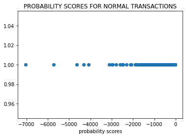

```python
plt.scatter(norm['guassian_score'],y)
plt.title("PROBABILITY SCORES FOR NORMAL TRANSACTIONS")
plt.xlabel('probability scores')
```

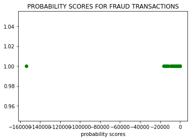

```python
plt.scatter(fraud1['guassian_score'],y2,c='green')
plt.title("PROBABILITY SCORES FOR FRAUD TRANSACTIONS")
plt.xlabel('probability scores')
```

```python
# set a threshold for markng a transcation as fraud or normal.
#setting threhold as 3500
```

```python
# Running isolation forest again using the Guassian scores as an engineered feature

test_data_gm = data_test.copy()
```

```python
test_data_gm['guassian_score'] = GM
```

```python
df2.columns
```

```
Index(['Time', 'V1', 'V2', 'V3', 'V4', 'V5', 'V6', 'V7', 'V8', 'V9', 'V10',
       'V11', 'V12', 'V13', 'V14', 'V15', 'V16', 'V17', 'V18', 'V19', 'V20',
       'V21', 'V22', 'V23', 'V24', 'V25', 'V26', 'V27', 'V28', 'Amount',
       'Class', 'guassian_score'],
      dtype='object')
```

```python
Xtrain_gm = df2.drop('Class',axis = 1)
Ytrain_gm = df2['Class']
model_if.fit(Xtrain_gm)
```

```
IsolationForest(contamination=0.00172, max_features=10, random_state=32)
```

```python
ypred_gm = model_if.predict(test_data_gm )
```

```python
print(classification_report(YTEST,ypred_gm))
```

```
              precision    recall  f1-score   support

          -1       0.24      0.23      0.24        98
           1       1.00      1.00      1.00     56864

    accuracy                           1.00     56962
   macro avg       0.62      0.62      0.62     56962
weighted avg       1.00      1.00      1.00     56962
```

```python
model_EE.fit(Xtrain_gm)
```

[output not shown]

[output cut: 362 more lines]

```
EllipticEnvelope(assume_centered=True, random_state=32)
```

```python
ytest[:100]
```

```
0     1
1     1
2     1
3     1
4     1
     ..
95    1
96    1
97    1
98    1
99    1
Name: Class, Length: 100, dtype: int64
```

```python
ypred_gm_ee = model_EE.predict(test_data_gm )
```

```python
print(classification_report(YTEST,ypred_gm_ee))
```

```
              precision    recall  f1-score   support

          -1       0.01      0.77      0.03        98
           1       1.00      0.90      0.95     56864

    accuracy                           0.90     56962
   macro avg       0.51      0.83      0.49     56962
weighted avg       1.00      0.90      0.95     56962
```

```python
model_svm = svm.SVC()
model_svm.fit(Xtrain_gm,Ytrain_gm)
```

```
SVC()
```

**SVM model Evaluation On test data**

```python
# Accuracy on test data
X_test_predict_svm = model_svm.predict(test_data_gm)
accuracy_test_svm = accuracy_score(YTEST,X_test_predict_svm)
```

```python
print(classification_report(YTEST,X_test_predict_svm))
```

```
              precision    recall  f1-score   support

          -1       0.00      0.00      0.00      98.0
           0       0.00      0.00      0.00       0.0
           1       0.00      0.00      0.00   56864.0

    accuracy                           0.00   56962.0
   macro avg       0.00      0.00      0.00   56962.0
weighted avg       0.00      0.00      0.00   56962.0
```

```python
print("Accuracy using SVM model on training data is ", accuracy_train_svm)
```

```
Accuracy using SVM model on training data is  0.9982718514779785
```

```python
print("Accuracy using SVM model on test data is ", accuracy_test_svm)
```

```
Accuracy using SVM model on test data is  0.0
```